# Observational Analysis: F1-Score

Julian Frattini

2025-02-17

This notebook contains the observational analysis of the impact of requirements quality (RQ) on the performance of trace link recovery (TLR) in terms of $F_1$-score.

## Data Loading

First, load the data for the observational analysis. The data set is procured by the data-preparation.Rmd notebook. This notebook assembles and casts the data appropriately and stores the results in the `rq4tlr-data.csv` file.

```r
df <- read.csv('./../data/rq4tlr-data.csv')
```

Scale all numeric variables to make their coefficient distributions easier to sample from.

```r
df <- df %>%
  mutate(across(
    c("size", "outlinks", "maxinlinks", "maxsteplength", "sencomplexity"),
    \(x) scale(x, center = TRUE))) %>%
  mutate(
    Approach = factor(Approach, levels=c("FTLR", "LiSSA", "IR", "VSM", "LSI"), ordered = FALSE),
    Category = factor(Category, levels=c("Embedding", "LLM", "Traditional"), ordered = FALSE),
  )

str(df)
```

```
## 'data.frame':    945 obs. of  41 variables:
##  $ Dataset         : chr  "etour" "etour" "etour" "etour" ...
##  $ File            : chr  "UC1" "UC1" "UC1" "UC1" ...
##  $ duplicate       : logi  FALSE FALSE FALSE FALSE FALSE FALSE ...
##  $ nameproblem     : logi  FALSE FALSE FALSE FALSE FALSE FALSE ...
##  $ scope           : logi  FALSE FALSE FALSE FALSE FALSE FALSE ...
##  $ textorder       : logi  FALSE FALSE FALSE FALSE FALSE FALSE ...
##  $ iounquantified  : logi  FALSE FALSE FALSE FALSE FALSE FALSE ...
##  $ actoractor      : logi  FALSE FALSE FALSE FALSE FALSE FALSE ...
##  $ justification   : logi  FALSE FALSE FALSE FALSE FALSE FALSE ...
##  $ coordambiguity  : num  0 0 0 0 0 0 0 0 0 0 ...
##  $ uidesign        : num  0 0 0 0 0 0 0 0 0 0 ...
##  $ alternative     : num  0 0 0 0 0 0 0 0 0 0 ...
##  $ inconsistentloa : num  0 0 0 0 0 0 0 0 0 0 ...
##  $ clarification   : num  0 0 0 0 0 0 0 0 0 0 ...
```

[output cut: 37 more lines]

The output shows by what factors the numeric variables were centered and scaled.

## Analysis

The analysis of the data employs a regression model in a Bayesian framework.

### Distribution

The outcome variable is bounded within $\in [0, 1]$. This makes a **Beta** distribution an eligible target distribution for the response variables. To determine which variant of the Beta distribution family can be chosen, we visualize the raw distribution.

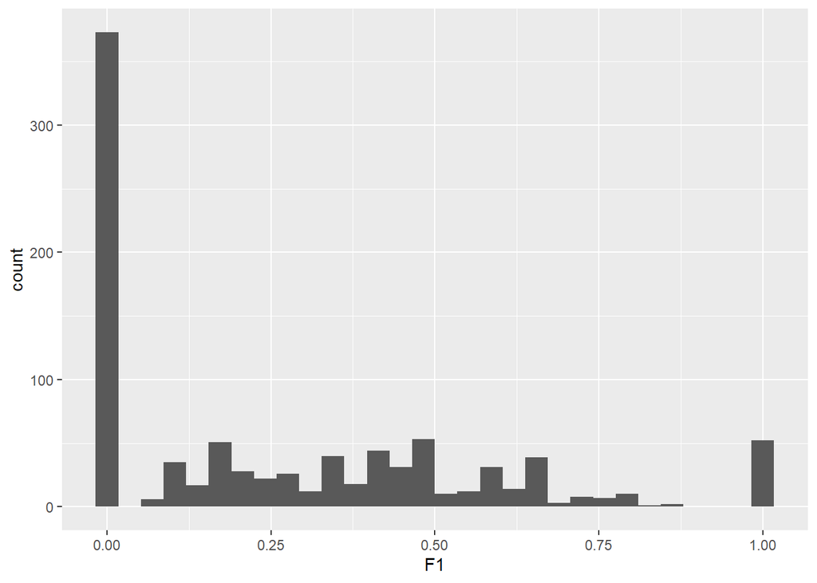

```r
df %>%
  select(F1) %>%
  ggplot(aes(x = F1)) +
    geom_histogram(bins = 30)
```

A base Beta distribution would require that all values are bounded within $]0; 1[$. The observed values for the outcome variable show a clear zero- and one-inflation. Hence, we chose the `zero_one_inflated_beta` distribution from the `brms` library.

### Formula

Next, we define a regression formula that puts the outcome variable of interest in relation to the predictors with which we assume a causal relationship.

```r
f1 <- F1 ~ 0 + Intercept +
  Dataset + Approach +
  sencomplexity + maxsteplength + size + inconsistentloa + uidesign +
  clarification + alternative + coherence + happy + lostfr + anaphora +
  nonnounstart + passive + negation + outlinks + maxinlinks
```

The `0 + Intercept` term instead of `1 +` or even complete omission stems from the fact that the regression formula contains at least one predictor that is not centered around 0.

### Priors

The selected regression formula requires the definition of prior distributions for the following parameters.

```r
get_prior(f1, data=df, family=zero_one_inflated_beta)
```

```
##              prior class            coef group resp dpar nlpar lb ub
##             (flat)     b
##             (flat)     b     alternative
##             (flat)     b        anaphora
##             (flat)     b      ApproachIR
##             (flat)     b   ApproachLiSSA
##             (flat)     b     ApproachLSI
##             (flat)     b     ApproachVSM
##             (flat)     b   clarification
##             (flat)     b       coherence
##             (flat)     b   Datasetitrust
##             (flat)     b       happyTRUE
##             (flat)     b inconsistentloa
##             (flat)     b       Intercept
##             (flat)     b      lostfrTRUE
##             (flat)     b      maxinlinks
##             (flat)     b   maxsteplength
##             (flat)     b        negation
##             (flat)     b    nonnounstart
##             (flat)     b        outlinks
##             (flat)     b         passive
##             (flat)     b   sencomplexity
##             (flat)     b            size
##             (flat)     b        uidesign
##         beta(1, 1)   coi                                        0  1
##  gamma(0.01, 0.01)   phi                                        0
##         beta(1, 1)   zoi                                        0  1
##        source
##       default
##  (vectorized)
##  (vectorized)
##  (vectorized)
##  (vectorized)
##  (vectorized)
##  (vectorized)
##  (vectorized)
##  (vectorized)
##  (vectorized)
##  (vectorized)
##  (vectorized)
##  (vectorized)
##  (vectorized)
##  (vectorized)
##  (vectorized)
##  (vectorized)
##  (vectorized)
##  (vectorized)
##  (vectorized)
##  (vectorized)
##  (vectorized)
##  (vectorized)
##       default
##       default
##       default
```

```r
p1 <- c(
  prior(normal(0, 1), class = b, coef = "Intercept"),
  prior(normal(0, 0.5), class = b),
  prior(gamma(4, 1), class = phi),
  prior(beta(7, 2), class = coi),
  prior(beta(5, 2), class = zoi)
)
```

### Prior Predictive Check

The prior predictive check helps determine the eligibility of the priors.

```r
m1.prior <-
  brm(data = df, family = zero_one_inflated_beta, f1, prior = p1,
    iter = 4000, warmup = 1000, chains = 4, cores = 4,
    seed = 4, sample_prior="only",
    file = "../fits/obs.f1.prior"
  )
```

In our particular case, the large number of predictors will, however, push the accumulated value of $\mu$ in the Beta-distribution to the to extremes.

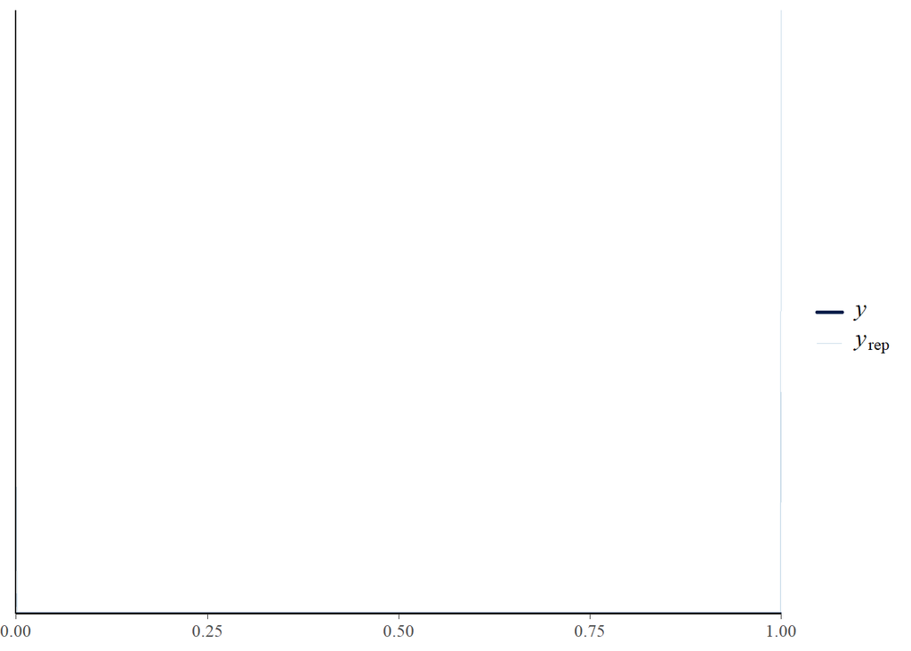

```r
brms::pp_check(m1.prior, ndraws=100)
```

The figure shows extreme concentrations of expected values $y_{rep}$ on the borders of the output space (at 0 and 1). This is expected due to the large number of predictors. Hence, we put more emphasis on the posterior predictive check.

### Training

Assuming the priors are reliable, we train the model by updating the coefficient parameters with the data `df`.

```r
m1 <-
  brm(data = df, family = zero_one_inflated_beta, f1, prior = p1,
    iter = 4000, warmup = 1000, chains = 4, cores = 4, seed = 4,
    file = "../fits/obs.f1"
  )
```

To check whether the training completed successfully, we inspect the posterior predictive check.

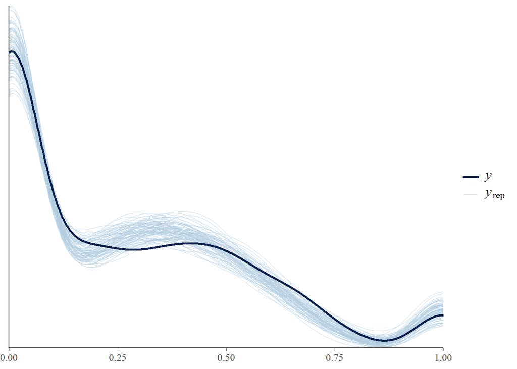

```r
brms::pp_check(m1, ndraws=100)
```

The output confirms that the model parameters have been updated properly and that the predicted outcomes $y_{rep}$ are close the the actual outcome $y$.

### Evaluation

Finally, we evaluate the model.

#### Coefficients

First, we look at the updated path coefficients in the model summary.

```r
summary(m1)
```

```
##  Family: zero_one_inflated_beta
##   Links: mu = logit; phi = identity; zoi = identity; coi = identity
## Formula: F1 ~ 0 + Intercept + Dataset + Approach + sencomplexity + maxsteplength + size + inconsistentloa + uidesign + clarification + alternative + coherence + happy + lostfr + anaphora + nonnounstart + passive + negation + outlinks + maxinlinks
##    Data: df (Number of observations: 945)
##   Draws: 4 chains, each with iter = 4000; warmup = 1000; thin = 1;
##          total post-warmup draws = 12000
##
## Regression Coefficients:
##                 Estimate Est.Error l-95% CI u-95% CI Rhat Bulk_ESS Tail_ESS
## Intercept          -0.41      0.16    -0.71    -0.10 1.00     6781     8219
## Datasetitrust       0.13      0.15    -0.17     0.43 1.00     7450     8226
## ApproachLiSSA       0.24      0.08     0.08     0.40 1.00     9028     8437
## ApproachIR         -0.76      0.09    -0.92    -0.59 1.00     9205     9156
## ApproachVSM         0.01      0.10    -0.18     0.20 1.00    10404     9343
## ApproachLSI         0.25      0.09     0.07     0.43 1.00    10239     9296
## sencomplexity       0.16      0.10    -0.04     0.37 1.00     9693     8605
## maxsteplength      -0.26      0.10    -0.46    -0.05 1.00     9383     8055
## size                0.05      0.04    -0.02     0.13 1.00    13167     9505
## inconsistentloa     0.11      0.18    -0.25     0.47 1.00    18940     9677
## uidesign           -0.33      0.37    -1.07     0.40 1.00    16874     9208
## clarification       0.10      0.17    -0.23     0.45 1.00    18138     8841
## alternative         0.33      0.27    -0.19     0.85 1.00    19332     9755
## coherence          -0.03      0.10    -0.23     0.17 1.00    16198     9841
## happyTRUE          -0.05      0.10    -0.23     0.14 1.00    11245     8517
## lostfrTRUE         -0.03      0.15    -0.33     0.26 1.00    23202     9179
## anaphora           -0.35      0.13    -0.59    -0.10 1.00    15739     9235
## nonnounstart       -0.09      0.12    -0.33     0.15 1.00     9558     8860
## passive             0.02      0.14    -0.25     0.29 1.00    12533     9517
## negation           -0.23      0.16    -0.55     0.09 1.00    18996     8829
## outlinks            0.30      0.04     0.21     0.38 1.00    14167     9633
## maxinlinks         -0.22      0.04    -0.30    -0.14 1.00    14261     9599
##
## Further Distributional Parameters:
##     Estimate Est.Error l-95% CI u-95% CI Rhat Bulk_ESS Tail_ESS
## phi     9.10      0.54     8.07    10.19 1.00    21543     8514
## zoi     0.45      0.02     0.42     0.48 1.00    21137     8663
## coi     0.14      0.02     0.11     0.17 1.00    20277     9033
##
## Draws were sampled using sampling(NUTS). For each parameter, Bulk_ESS
## and Tail_ESS are effective sample size measures, and Rhat is the potential
## scale reduction factor on split chains (at convergence, Rhat = 1).
```

These coefficients can also be visualized via a `mcmc_plot`.

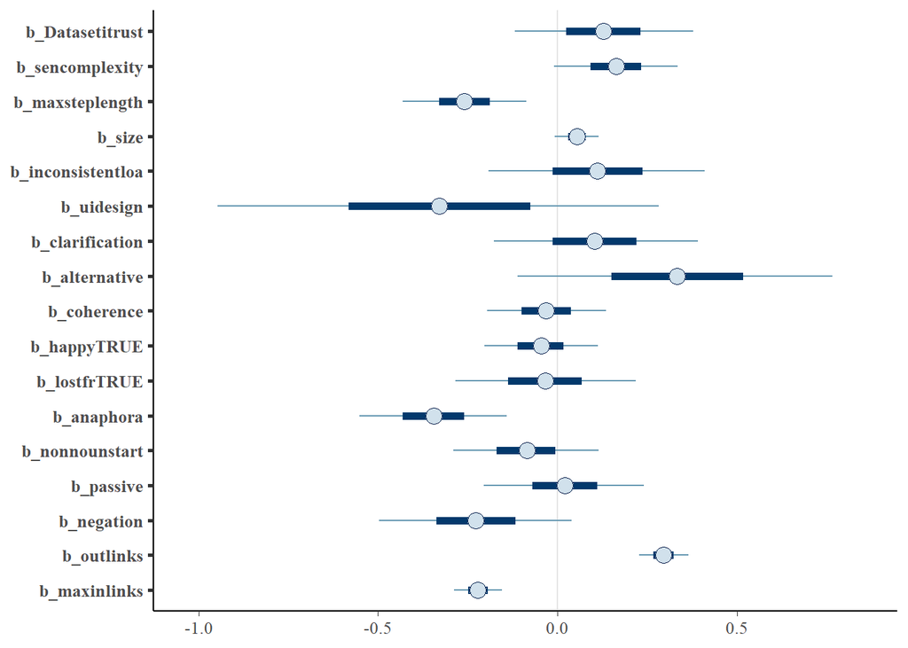

```r
mcmc_plot(m1, variable=c("b_Datasetitrust", "b_sencomplexity", "b_maxsteplength", "b_size", "b_inconsistentloa", "b_uidesign", "b_clarification", "b_alternative", "b_coherence", "b_happyTRUE", "b_lostfrTRUE", "b_anaphora", "b_nonnounstart", "b_passive", "b_negation", "b_outlinks", "b_maxinlinks"))
```

Variables, where the 50% confidence interval of the intercept does not overlap 0, weakly impact the response variable. Variables, where the 95% confidence interval of the intercept does not overlap 0, strongly impact the response variable.

#### Marginal Effects

For a clearer picture, we can plot the marginal effect of any predictor on the outcome variable. The marginal effect isolates the effect of the predictor on the outcome while keeping all other predictors constant at a representative level.

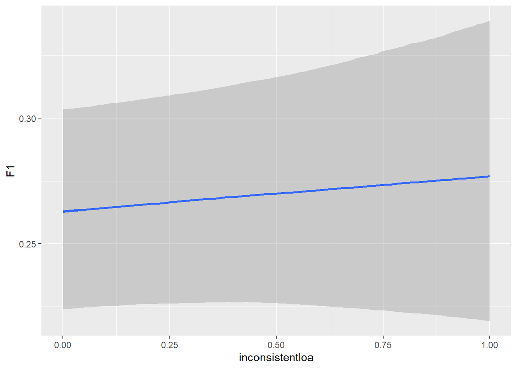

```r
conditional_effects(m1, effects="inconsistentloa", method="posterior_epred")
```

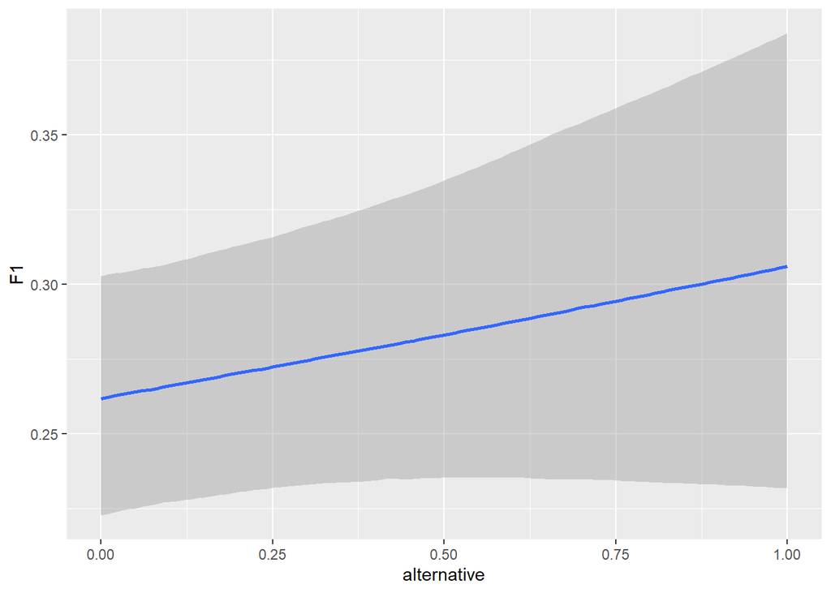

```r
conditional_effects(m1, effects="alternative", method="posterior_epred")
```

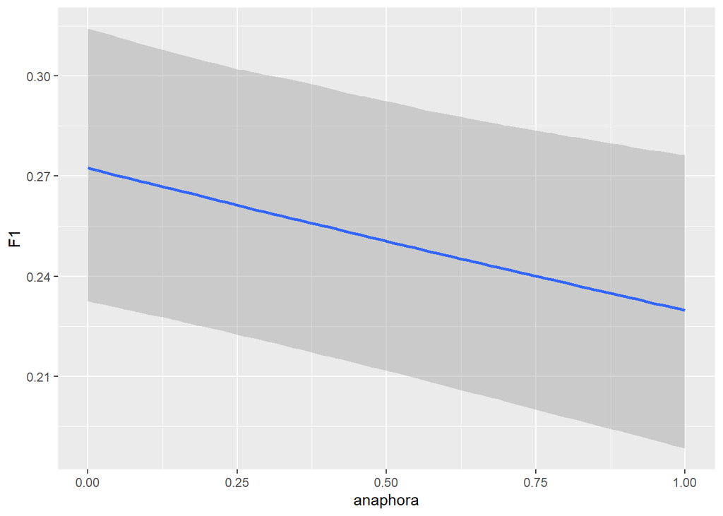

```r
conditional_effects(m1, effects="anaphora", method="posterior_epred")
```

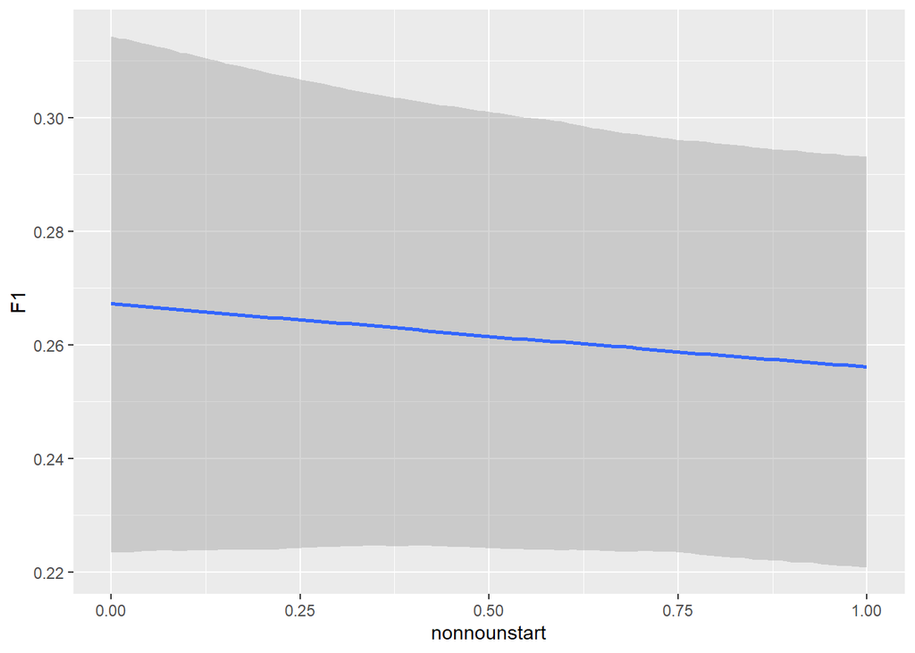

```r
conditional_effects(m1, effects="nonnounstart", method="posterior_epred")
```

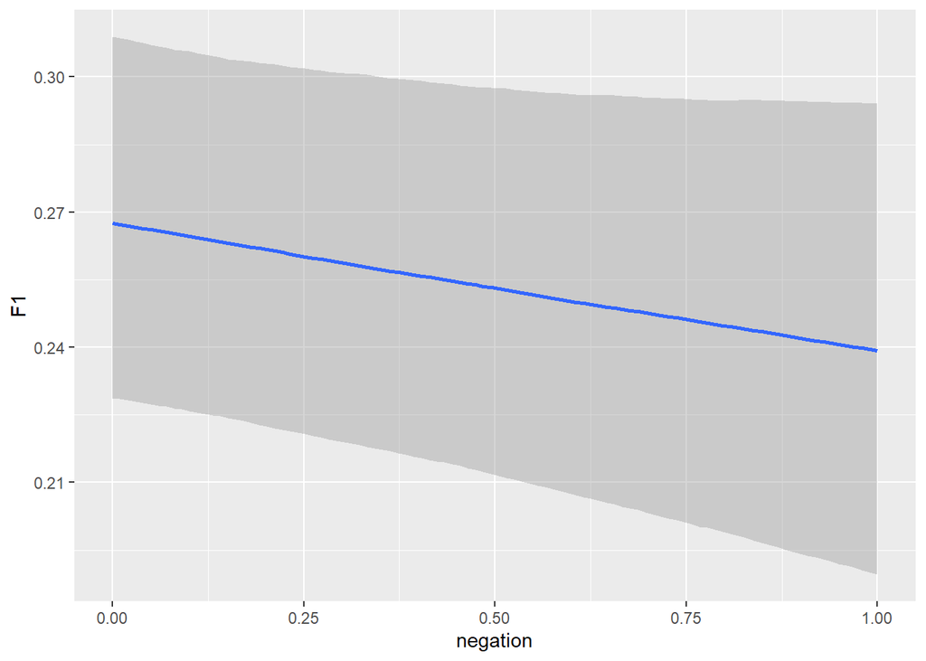

```r
conditional_effects(m1, effects="negation", method="posterior_epred")
```

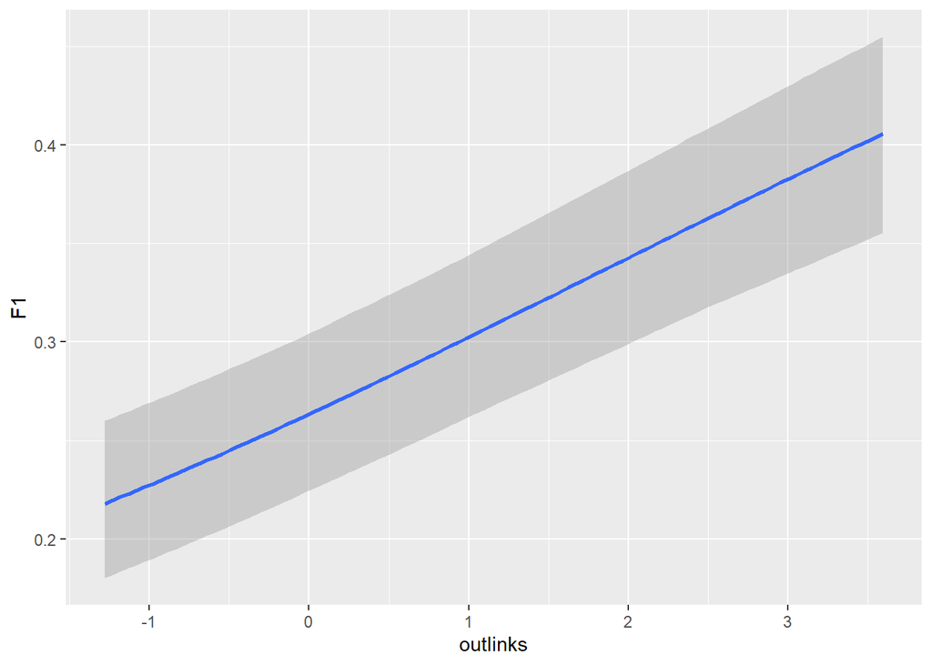

```r
conditional_effects(m1, effects="outlinks", method="posterior_epred")
```

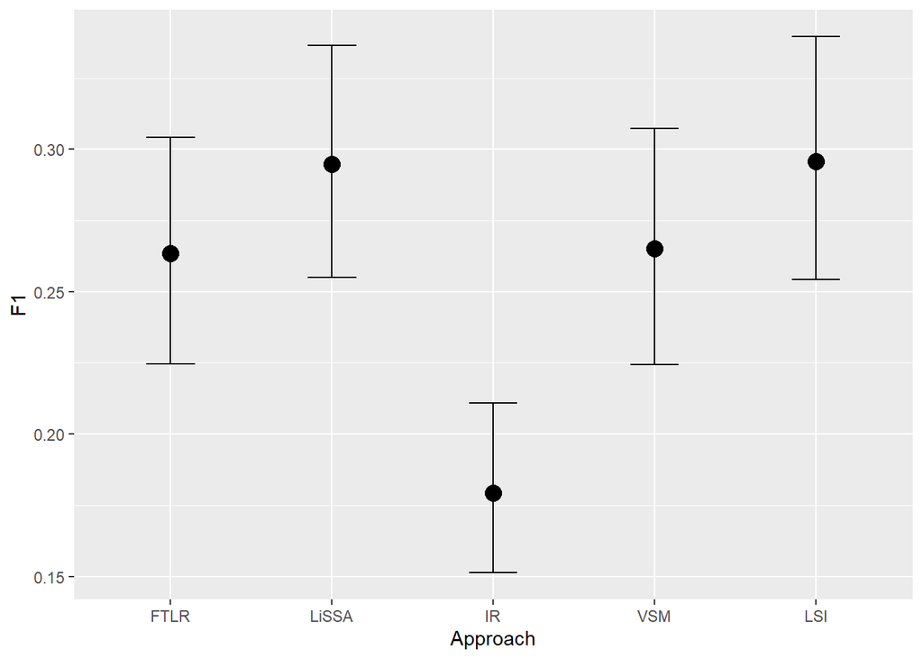

```r
conditional_effects(m1, effects="Approach", method="posterior_epred")
```

Particularly, we extract the marginal values for the effect on *Contains Alternatives* (`alternative`), *Contains Anaphora* (`anaphora`), and *Tangled Requirements* (`outlinks`) to visualize them (side-by-side with all other metrics).

```r
c.eff.alternatives <- conditional_effects(m1, effects="alternative", method="posterior_epred")

c.eff.alternatives$alternative %>%
  select(alternative, estimate__, lower__, upper__) %>%
  rename(all_of(c(
    mean = "estimate__",
    lower = "lower__",
    upper = "upper__"
  ))) %>%
  mutate(metric = "F1") %>%
  write_csv(file = "../data/estimates/marginal-alternatives-f1.csv")
```

```r
c.eff.anaphora <- conditional_effects(m1, effects="anaphora", method="posterior_epred")

c.eff.anaphora$anaphora %>%
  select(anaphora, estimate__, lower__, upper__) %>%
  rename(all_of(c(
    mean = "estimate__",
    lower = "lower__",
    upper = "upper__"
  ))) %>%
  mutate(metric = "F1") %>%
  write_csv(file = "../data/estimates/marginal-anaphora-f1.csv")
```

When exporting the marginal effects of the `outlinks` variable, we can directly revert the centering and scaling from the beginning (with $\mu=3.15$ and $\sigma=2.46$).

```r
c.eff.outlinks <- conditional_effects(m1, effects="outlinks", method="posterior_epred")

c.eff.outlinks$outlinks %>%
  select(outlinks, estimate__, lower__, upper__) %>%
  rename(all_of(c(
    mean = "estimate__",
    lower = "lower__",
    upper = "upper__"
  ))) %>%
  mutate(
    outlinks = outlinks*2.46 + 3.15,
    metric = "F1"
    ) %>%
  write_csv(file = "../data/estimates/marginal-outlinks-f1.csv")
```

## Store Data

Finally, we store the estimates of the posterior distributions in a new data frame and export it. This allows the estimate-visualization script to generate one figure of the posterior distributions from all response variables.

```r
summary(m1)$fixed %>%
  select(Estimate, Est.Error) %>%
  rename(all_of(c(
    mean = "Estimate",
    var = "Est.Error"))) %>%
  rownames_to_column("coef") %>%
  write_csv(file = "../data/estimates/obs-f1.csv")
```

Additionally, we store the the draws from the expected value of the posterior predictive distribution for the different approaches to compare how they perform in general. This is the data from the above rendered marginal plots.

```r
t <- conditional_effects(m1, effects="Approach", method="posterior_epred")
t$Approach %>%
  select(c("Approach", "estimate__", "se__")) %>%
  write_csv(file = "../data/estimates/marginal-approaches-f1.csv")
```